# Part II - Ford GoBike System Data

## by Kiprop Yano

## Investigation Overview

The goal of this presentation is to provide an insight on the average trip duration among the users. Also, it will highlight the days the highest and lowest days of the week users use the bikes.

## Dataset Overview

The dataset used in this project in the Ford GoBike System Data. This data set includes information about individual rides made in a bike-sharing system covering the greater San Francisco Bay area.

## Number of Users

There are 160,000 susbscribed users and 20,000 customers. From the pie chart, it indicates that most users (89.2%) are subscribers more than the actual customers who comprise only 10.8%.

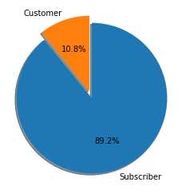

### Age distribution

Most users are aged between 20 and 40 years.

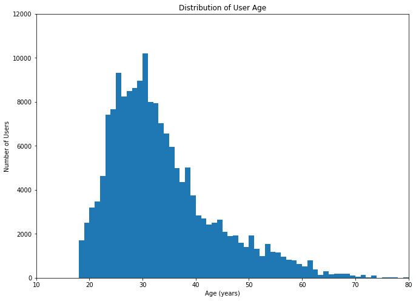

## Average trip duration

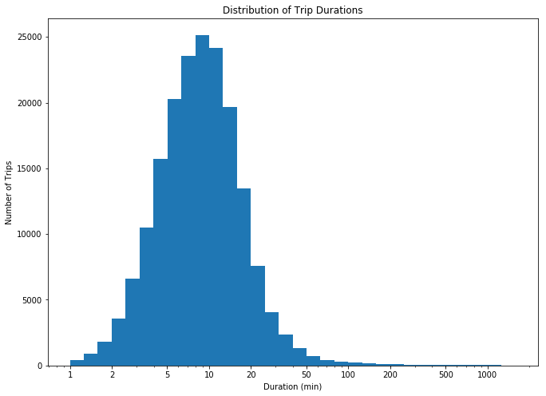

## Trip duration and gender

The box plot shows that females have longer trips as compared to males, despite the fact that females are fewer as opposed to male users.

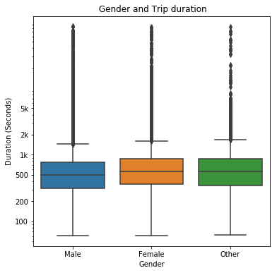